# 03_sin_amp

## 03_sin_amp

#### Question

1. Below is a graph of $y=A\cdot \sin(t)$ and, as a dotted line, the parent function $y=\sin(t)$.

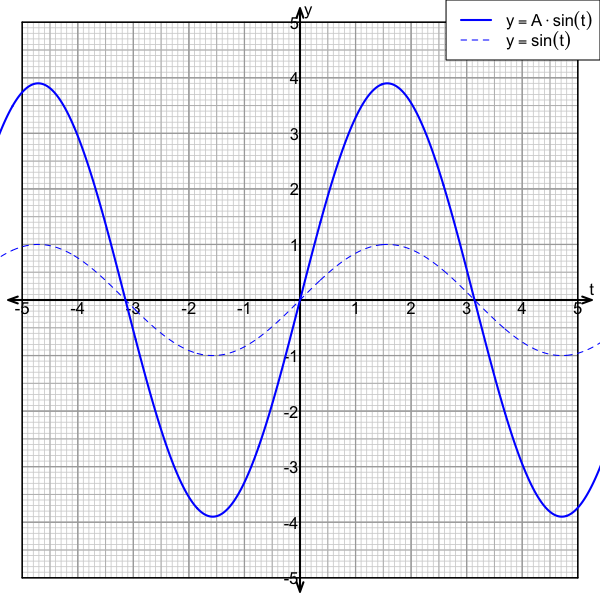

   What is the value of $A$?

#### Question

2. Below is a graph of $y=A\cdot \sin(t)$ and, as a dotted line, the parent function $y=\sin(t)$.

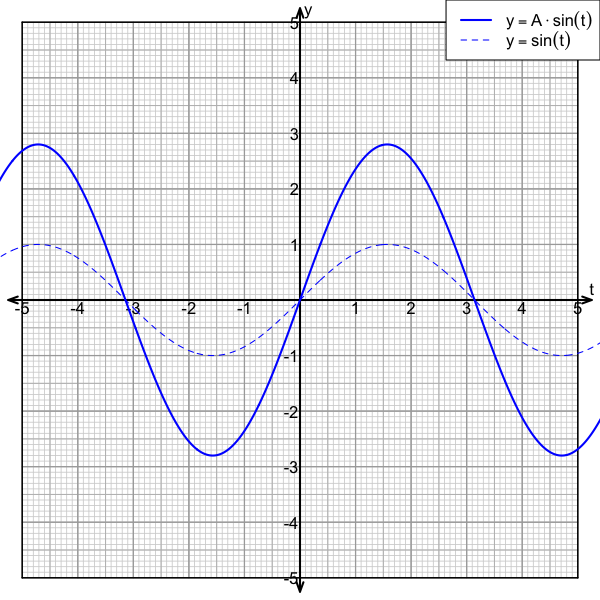

   What is the value of $A$?

#### Question

3. Below is a graph of $y=A\cdot \sin(t)$ and, as a dotted line, the parent function $y=\sin(t)$.

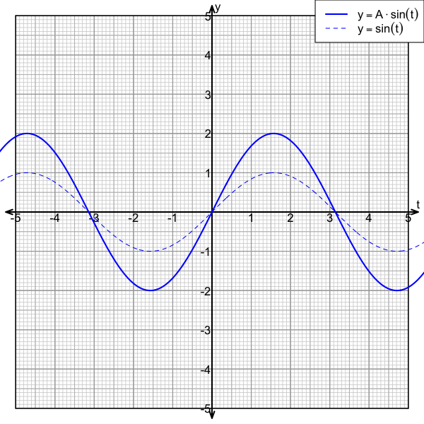

   What is the value of $A$?

#### Question

4. Below is a graph of $y=A\cdot \sin(t)$ and, as a dotted line, the parent function $y=\sin(t)$.

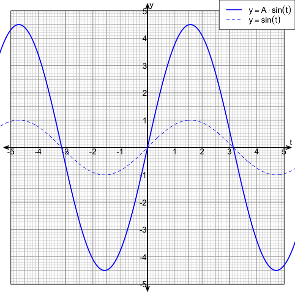

   What is the value of $A$?

#### Question

5. Below is a graph of $y=A\cdot \sin(t)$ and, as a dotted line, the parent function $y=\sin(t)$.

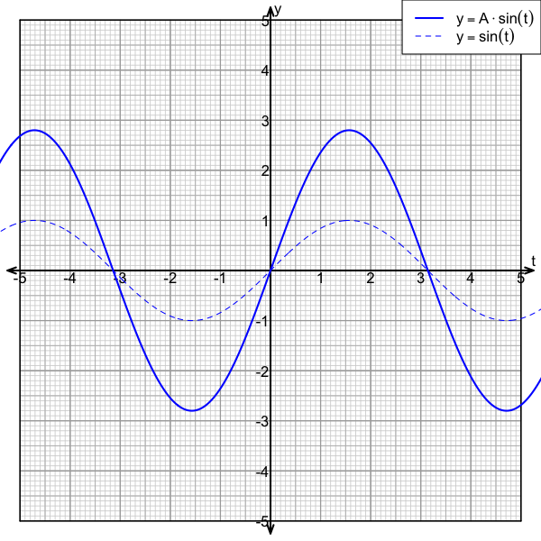

   What is the value of $A$?

#### Question

6. Below is a graph of $y=A\cdot \sin(t)$ and, as a dotted line, the parent function $y=\sin(t)$.

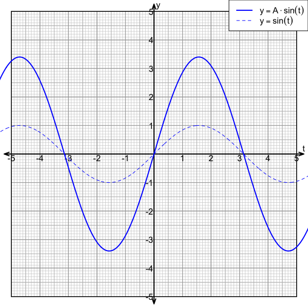

   What is the value of $A$?

#### Question

7. Below is a graph of $y=A\cdot \sin(t)$ and, as a dotted line, the parent function $y=\sin(t)$.

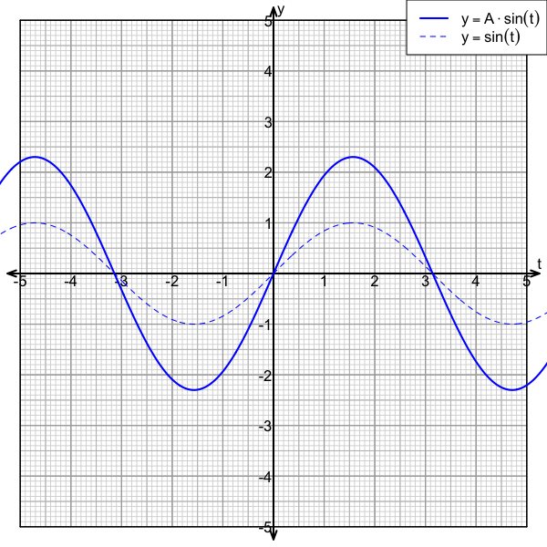

   What is the value of $A$?

#### Question

8. Below is a graph of $y=A\cdot \sin(t)$ and, as a dotted line, the parent function $y=\sin(t)$.

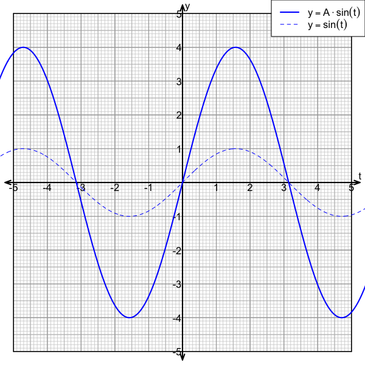

   What is the value of $A$?